# MFE5209 ARCH/GARCH

Wu Fuheng

Monday, October 06, 2014

### Problem 1

> EMAIL: [Wu Fuheng(a0095704@nus.edu.sg)](http://rpubs.com/wujucong/32751)

This is a AR(1)/ARCH(1) model, the conditional mean and variance of $u_t$ will be **non-constant**.

Since $\mu=0.4, \phi=0.45, \omega=1$ and $\alpha_1=0.3$, we can rewrite the equation of $u_t$ as follows:

$\begin{align*} u_t &=(1-\phi)\mu + \phi u_{t-1} + h_t\\ &=(1-0.45)0.4+0.45 u_{t-1}+h_t\\ &=0.22+0.45 u_{t-1}+h_t\\ \end{align*}$

> **a)**Conditional Expectation

The conditional mean of $u_t$ is

$\begin{align*} E[u_t|u_{t-1},...] &= 0.22+0.45u_{t-1}+E[h_t|h_{t-1}...]\\ \end{align*}$

According to P479 of *SDAFE*, for a ARCH(1) process $h_t$, the conditional mean $E[h_t|h_{t-1}...]$=0. Thus we have

$\begin{align*} E[u_t|u_{t-1},...] &= 0.22+0.45u_{t-1}\\ \end{align*}$

So,

$\begin{align*} E[u_2|u_1=1,u_0=0.2] &= 0.22+0.45u_1\\ &=0.67 \end{align*}$

> **b)**Conditional Variance

The conditional variance of $u_t$ is $\begin{align*} Var[u_t|u_{t-1},...] &= E[(u_t-E[u_t|u_{t-1},...])^2|u_{t-1},...]\\ &= E[(h_t)^2|u_{t-1},...]\\ &= \omega + \alpha_1 h_{t-1}^2\\ \end{align*}$

Thus, we have $\begin{align*} Var[u_2|u_1=1,u_0=0.2] &= \omega + \alpha_1 h_{1}^2\\ &= 1 + 0.3 h_{1}^2\\ \end{align*}$

And we also know $\begin{align*} u_1-\mu=\phi (u_0 - \mu) + h_1\\ \longrightarrow 1-0.4=0.45(0.2-0.4)+ h_1\\ \longrightarrow h_1=0.6+0.45 \times 0.2=0.69 \end{align*}$

Therefore, $Var[u_2|u_1=1,u_0=0.2]=1+0.3 \times 0.69^2=1.14283$

### Problem 2

Assume $\beta_0=0.06, \beta_1=0.35, \delta=0.22$, we can rewrite the model

$\begin{align*} Y_t=0.06+0.35X_t+0.22\sigma_t+h_t \end{align*}$

> **a)**Conditional Expectation

$\begin{align*} E[Y_t|X_t=0.1,h_{t-1}=0.6] &=0.06+0.35*0.1+0.22\sigma_t\\ &=0.095+0.22\sigma_t\\ \end{align*}$

> **b)**Conditional Variance

$\begin{align*} Var[Y_t|X_t=0.1,h_{t-1}=0.6] &=E[(Y_t-E[Y_t|X_t=0.1,h_{t-1}=0.6])^2|X_t=0.1,h_{t-1}=0.6]\\ &=E[h_t^2|X_t=0.1,h_{t-1}=0.6]\\ &=1+0.5h_{t-1}^2\\ &=1+0.5*0.6^2\\ &=1.18 \end{align*}$

> **c)**Is the conditional distribution of $Y_t$ given $X_t$ and $h_{t-1}$ normal? Why or why not?

Yes, it is normal. Reason: There is only one stochastic item $\varepsilon$ in the formula which is normal. And we know the linear combination of a normal distribution is normal.

> **d)**Is the marginal distribution of $Y_t$ normal? Why or why not?

No, it isn’t. Reason: In this case, $h_t$ is a ARCH(1) process, which is of a non-Gaussian distribution with a heavy tail. So $Y_t$ is also not Gaussian/normal.

### Problem 3

This problem uses monthly observations of the two-month yield, that is, $Y_T$ with T equal to two months, in the data set Irates in the Ecdat package. The rates are log-transformed to stabilize the variance. To fit a GARCH model to the changes in the log rates, run the following R code.

```r
library(fGarch)
library(Ecdat)
data(Irates)
r = as.numeric(log(Irates[,2]))
n = length(r)
lagr = r[1:(n-1)]
diffr = r[2:n] - lagr
g=garchFit(~arma(1,0)+garch(1,1),data=diffr, cond.dist = "std")
```

> **a)** What model is being fit to the changes in $r$? Describe the model in detail.

The model is a AR(1)/GARCH(1,1) model, assuming a t-distributed errors. We are trying to use AR(1) to model the return conditional mean and GARCH(1,1) to model its conditional variance. We can write is mathematically as follows:

$\begin{align*} \Delta r_t=Y_t=\mu+ar_1 Y_{t-1}+a_t\\ \\ a_t=\varepsilon_t \sqrt{\omega + \alpha_1 a_{t-1}^2+ \beta_1 \sigma_{t-1}^2}, \varepsilon_t \thicksim t(.) \end{align*}$

In this case, the fitted model is: $\begin{align} \Delta r_t=Y_t=0.00910873+0.09508060 Y_{t-1}+a_t\\ \\ a_t=\varepsilon_t \sqrt{0.00054864 + 0.32444019 a_{t-1}^2+ 0.74026870 \sigma_{t-1}^2}\\ \\ \varepsilon_t \thicksim t(2.83060758) \end{align}$

The details of the fitted model are as follows:

```r
summary(g)
```

```
##
## Title:
##  GARCH Modelling
##
## Call:
##  garchFit(formula = ~arma(1, 0) + garch(1, 1), data = diffr, cond.dist = "std")
##
## Mean and Variance Equation:
##  data ~ arma(1, 0) + garch(1, 1)
## <environment: 0x000000000b8aa668>
##  [data = diffr]
##
## Conditional Distribution:
##  std
##
## Coefficient(s):
##         mu         ar1       omega      alpha1       beta1       shape
## 0.00910873  0.09508060  0.00054864  0.32444019  0.74026870  2.83060758
##
## Std. Errors:
##  based on Hessian
##
## Error Analysis:
##         Estimate  Std. Error  t value Pr(>|t|)
## mu     0.0091087   0.0023895    3.812 0.000138 ***
## ar1    0.0950806   0.0432758    2.197 0.028014 *
## omega  0.0005486   0.0002968    1.848 0.064564 .
## alpha1 0.3244402   0.1368876    2.370 0.017782 *
## beta1  0.7402687   0.0656629   11.274  < 2e-16 ***
## shape  2.8306076   0.4243716    6.670 2.56e-11 ***
## ---
## Signif. codes:  0 '***' 0.001 '**' 0.01 '*' 0.05 '.' 0.1 ' ' 1
##
## Log Likelihood:
##  630.9    normalized:  1.19
##
## Description:
##  Sat Oct 11 00:48:12 2014 by user: wufuh_000
##
##
## Standardised Residuals Tests:
##                                 Statistic p-Value
##  Jarque-Bera Test   R    Chi^2  1048      0
##  Shapiro-Wilk Test  R    W      0.9114    0
##  Ljung-Box Test     R    Q(10)  7.962     0.6326
##  Ljung-Box Test     R    Q(15)  11.93     0.6846
##  Ljung-Box Test     R    Q(20)  12.76     0.8874
##  Ljung-Box Test     R^2  Q(10)  13.12     0.2173
##  Ljung-Box Test     R^2  Q(15)  14.7      0.4736
##  Ljung-Box Test     R^2  Q(20)  17.79     0.6014
##  LM Arch Test       R    TR^2   14.28     0.2829
##
## Information Criterion Statistics:
##    AIC    BIC    SIC   HQIC
## -2.358 -2.310 -2.358 -2.339
```

> **b)** What are the estimates of the parameters of the model?

The estimates of the model parameters are as follows

```
Coefficient(s):
         mu         ar1       omega      alpha1       beta1       shape
 0.00910873  0.09508060  0.00054864  0.32444019  0.74026870  2.83060758
```

> **c)** What is the estimated ACF of $\Delta r_t$ ?

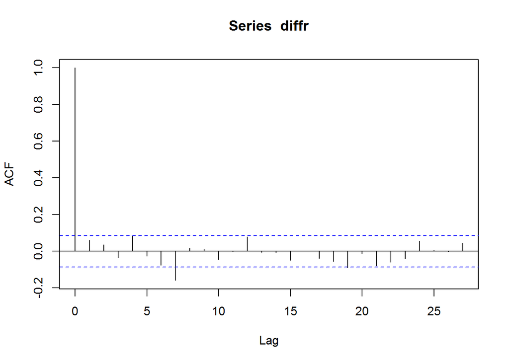

```r
acf(diffr)
```

> **d)** What is the estimated ACF of $a_t$ ?

$a_t$ is uncorrelated, aka $ACF(a_t)=\rho_a(h)=0$ if $h\neq 0$.

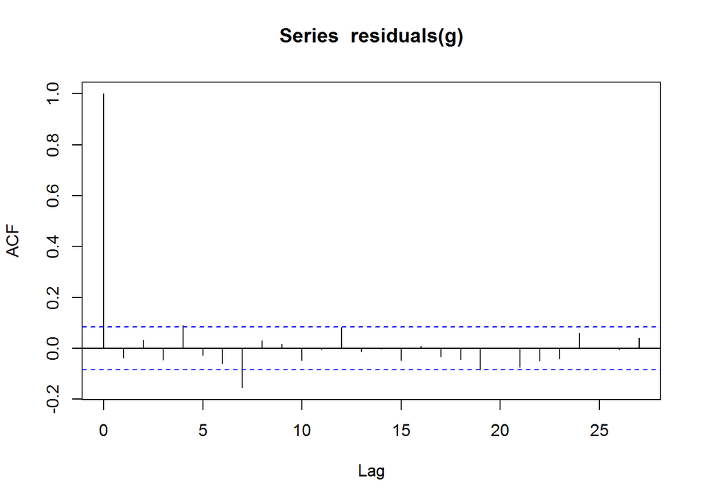

```r
acf(residuals(g))
```

> **e)** What is the estimated ACF of ${a_t}^2$ ?

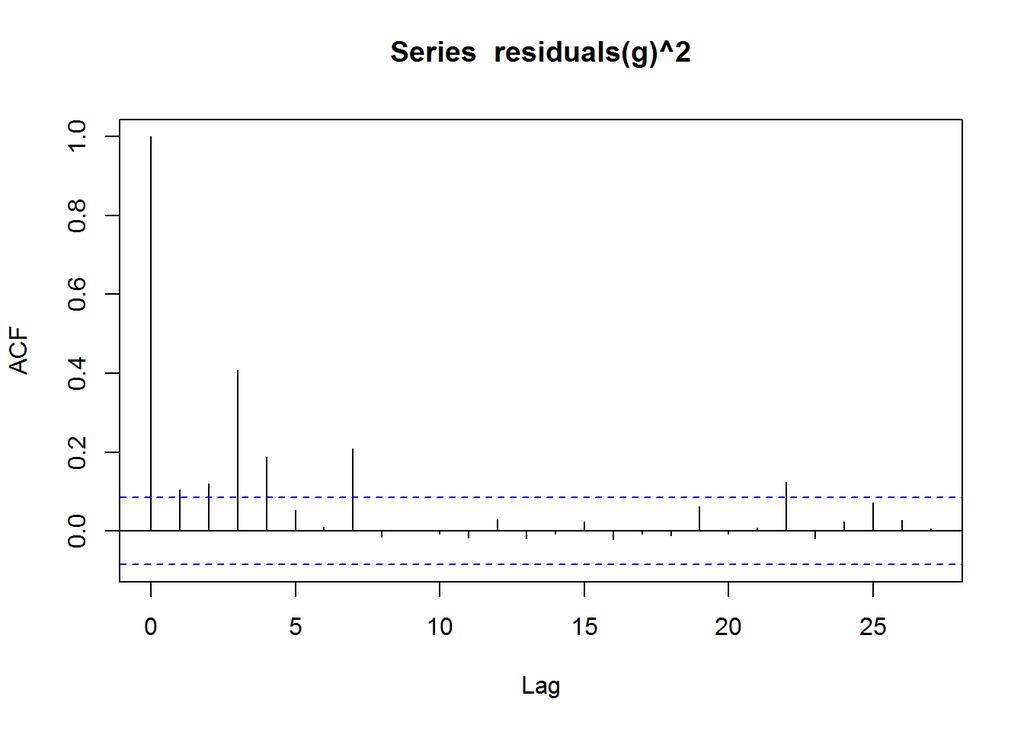

```r
acf(residuals(g)^2)
```